# OCR com Python e Tesseract

# Reconhecimento de texto em imagens

## Instalando o Tesseract

Documentação: https://pypi.org/project/pytesseract/

```python
#!sudo apt install tesseract-ocr
!pip install pytesseract
```

```python
!pip install --user opencv-python-headless==4.5.2.52
```

## Importando as bibliotecas

```python
import os
```

```python
import pytesseract
import numpy as np
import cv2 # OpenCV
#from google.colab.patches import cv2_imshow
```

```python
import matplotlib.pyplot as plt
```

```python
%matplotlib inline
```

## Leitura da imagem

```python
img = cv2.imread('../Imagens/teste01.jpg') # BGR (RGB)
```

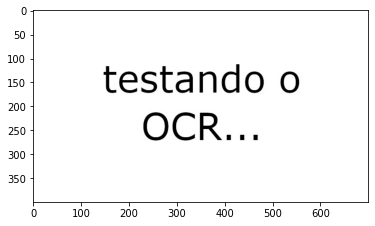

```python
plt.imshow(img)
plt.show()
```

```python
# OBTENDO OS CANAIS DE CORES SEPARADAS

B, G, R = cv2.split(img)
```

```python
# REALIZANDO A CONVERSÃO PARA RGB

img_rgb = cv2.cvtColor(img, cv2.COLOR_BGR2RGB)
```

Se as imagens estivessem coloridas, haveria uma mudança perceptível nas cores.

```python
#from google.colab import drive
#drive.mount('/content/drive')
```

```python
texto = pytesseract.image_to_string(img_rgb)
```

```python
print(texto)
```

```
testando o
OCR...
```

## Suporte para caracteres e símbolos de outros idiomas

```python
img = cv2.imread('../Imagens/teste02.jpg')
```

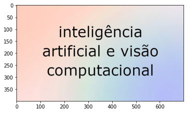

```python
plt.imshow(img)
plt.show()
```

```python
texto = pytesseract.image_to_string(img)
print(texto)
```

```
inteligéncia
artificial e visao
computacional
```

```python
rgb = cv2.cvtColor(img, cv2.COLOR_BGR2RGB)
```

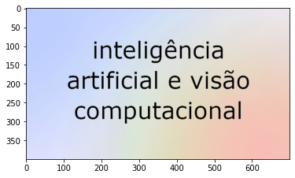

```python
plt.imshow(rgb)
plt.show()
```

```python
texto = pytesseract.image_to_string(rgb)
print(texto) # resumé, fiancé, déjà vu
```

```
inteligéncia
artificial e visao
computacional
```

```python
!tesseract --list-langs
```

```
List of available languages (159):
afr
amh
ara
asm
aze
aze_cyrl
bel
ben
bod
bos
bre
bul
cat
ceb
ces
chi_sim
chi_sim_vert
chi_tra
chi_tra_vert
chr
cos
cym
dan
deu
div
dzo
ell
eng
enm
epo
est
eus
fao
fas
fil
fin
fra
frk
frm
```

[output cut: 105 more lines]

```
tat
tel
tgk
tha
tir
ton
tur
uig
ukr
urd
uzb
uzb_cyrl
vie
yid
yor
```

```python
#!apt-get install tesseract-ocr-por
```

```python
texto = pytesseract.image_to_string(rgb, lang='por')
print(texto)
```

```
inteligência
artificial e visão
computacional
```

```python
# CRIANDO UMA PASTA PARA SALVAR OS MODELOS EM OUTRAS LANG
```

```python
tessdata_dir = r'C:\Users\Emerson\Desktop\Analytics\MATERIAIS POR TEMA\OCR\TESSERACT\tessdata_best'
```

```python
# Set environment variables
os.environ['TESSDATA_PREFIX'] = tessdata_dir
```

```python
texto = pytesseract.image_to_string(rgb, lang='por')
print(texto)
```

```
inteligência
artificial e visão
computacional
```

## Parâmetros

### Page segmentation modes (PSM)

```python
!tesseract --help-psm
```

```
Page segmentation modes:
  0    Orientation and script detection (OSD) only.
  1    Automatic page segmentation with OSD.
  2    Automatic page segmentation, but no OSD, or OCR. (not implemented)
  3    Fully automatic page segmentation, but no OSD. (Default)
  4    Assume a single column of text of variable sizes.
  5    Assume a single uniform block of vertically aligned text.
  6    Assume a single uniform block of text.
  7    Treat the image as a single text line.
  8    Treat the image as a single word.
  9    Treat the image as a single word in a circle.
 10    Treat the image as a single character.
 11    Sparse text. Find as much text as possible in no particular order.
 12    Sparse text with OSD.
 13    Raw line. Treat the image as a single text line,
       bypassing hacks that are Tesseract-specific.
```

```python
img = cv2.imread('../Imagens/trecho-livro.jpg')
rgb = cv2.cvtColor(img, cv2.COLOR_BGR2RGB)
```

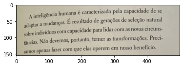

```python
plt.imshow(rgb)
plt.show()
```

```python
# SEM NENHUMA OPÇÃO

texto = pytesseract.image_to_string(rgb, lang='por')
print(texto)
```

```
A inteligência humana é caracterizada pela capacidade de se
adaptar a mudanças. É resultado de gerações de seleção natural
Sobre indivíduos com capacidade para lidar com as novas ciruns-
portanto, temer as transformações. Preci-

tâncias. Não devemos,
samos apenas fazer com que elas operem em nosso benefício.
```

```python
# PSM 6 - Considere um único bloco de texto uniforme.

config_tesseract = '--psm 6'
texto = pytesseract.image_to_string(rgb, lang='por', config=config_tesseract)
print(texto)
```

```
A inteligência humana é caracterizada pela capacidade de se
adaptar a mudanças. É resultado de gerações de seleção natural
Sobre indivíduos com capacidade para lidar com as novas ciruns-
tâncias. Não devemos, portanto, temer as transformações. Preci-
samos apenas fazer com que elas operem em nosso benefício.
```

```python
pytesseract.get_tesseract_version()
```

```
LooseVersion ('4.0.0.20190314
 leptonica-1.78.0
  libgif 5.1.4 : libjpeg 8d (libjpeg-turbo 1.5.3) : libpng 1.6.34 : libtiff 4.0.9 : zlib 1.2.11 : libwebp 0.6.1 : libopenjp2 2.2.0
 Found AVX
 Found SSE
')
```

```python
# Trate a imagem como uma única linha de texto.

config_tesseract = '--psm 7'
texto = pytesseract.image_to_string(rgb, lang='por', config=config_tesseract)
print(texto)
```

```
EE
```

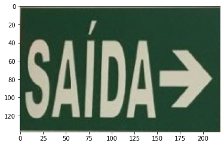

```python
img = cv2.imread('../Imagens/saida.jpg')
rgb = cv2.cvtColor(img, cv2.COLOR_BGR2RGB)
plt.imshow(rgb)
plt.show()
```

```python
# SEM NENHUMA OPÇÃO

texto = pytesseract.image_to_string(rgb, lang='por')
print(texto)
```

```
SAÍDAS
```

```python
# PSM 7 - Trate a imagem como uma única linha de texto.

config_tesseract = '--psm 7'
texto = pytesseract.image_to_string(rgb, lang='por', config=config_tesseract)
print(texto)
```

```
SAÍDAS
```

```python
# TESTANDO PSM 4 A PSM 13 COM A IMAGEM RGB

for i in range(4, 14):

    config_tesseract = '--psm {}'.format(i)
    texto = pytesseract.image_to_string(rgb, lang='por', config=config_tesseract)
    print(texto)
```

```
SAÍDAS

E
=

SAÍDAS

SAÍDAS

SAÍDA>

E

SAÍDA>

SAÍDAS

SAÍDAS

SAÍDA>
```

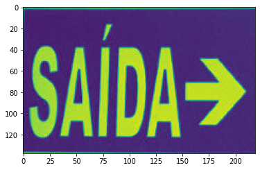

```python
# REALIZANDO A LEITURA E CONVERTENDO A IMAGEM PARA GRAY

img = cv2.imread('../Imagens/saida.jpg')
rgb = cv2.cvtColor(img, cv2.COLOR_BGR2GRAY)
plt.imshow(rgb)
plt.show()
```

```python
# TESTANDO PSM 4 A PSM 13 COM A IMAGEM GRAY

for i in range(4, 14):

    print("PSM ATUAL: {}".format(i))
    config_tesseract = '--psm {}'.format(i)
    texto = pytesseract.image_to_string(rgb, lang='por', config=config_tesseract)
    print(texto)
```

```
PSM ATUAL: 4
SAÍDAS

PSM ATUAL: 5
E
=

PSM ATUAL: 6
SAÍDAS

PSM ATUAL: 7
SAÍDAS

PSM ATUAL: 8
SAÍDA>

PSM ATUAL: 9
E

PSM ATUAL: 10
SAÍDA>

PSM ATUAL: 11
SAÍDAS

PSM ATUAL: 12
SAÍDAS

PSM ATUAL: 13
SAÍDA>
```

### Detecção de orientação da página

```python
from PIL import Image
import matplotlib.pyplot as plt
```

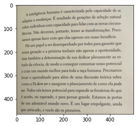

```python
img = Image.open('../Imagens/livro01.jpg')
plt.imshow(img)
```

```python
print(pytesseract.image_to_osd(img))
```

```
Page number: 0
Orientation in degrees: 0
Rotate: 0
Orientation confidence: 1.77
Script: Latin
Script confidence: 13.33
```

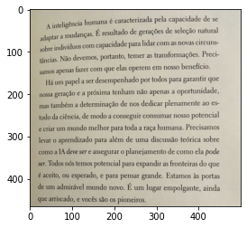

```
Page number: 0
Orientation in degrees: 0
Rotate: 0
Orientation confidence: 1.88
Script: Latin
Script confidence: 9.79
```

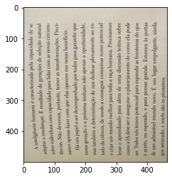

```
Page number: 0
Orientation in degrees: 270
Rotate: 90
Orientation confidence: 2.79
Script: Latin
Script confidence: 11.67
```

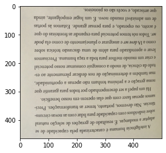

```
Page number: 0
Orientation in degrees: 180
Rotate: 180
Orientation confidence: 0.02
Script: Latin
Script confidence: 6.47
```

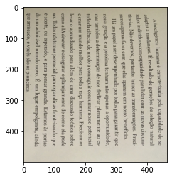

```
Page number: 0
Orientation in degrees: 90
Rotate: 270
Orientation confidence: 2.96
Script: Latin
Script confidence: 8.67
```

```python
for i in range(0, 4):

    rotateimage = np.rot90(img, i)

    plt.imshow(rotateimage)
    plt.show()

    print(pytesseract.image_to_osd(rotateimage))
```

```python
!tesseract --help-psm
```

```
Page segmentation modes:
  0    Orientation and script detection (OSD) only.
  1    Automatic page segmentation with OSD.
  2    Automatic page segmentation, but no OSD, or OCR. (not implemented)
  3    Fully automatic page segmentation, but no OSD. (Default)
  4    Assume a single column of text of variable sizes.
  5    Assume a single uniform block of vertically aligned text.
  6    Assume a single uniform block of text.
  7    Treat the image as a single text line.
  8    Treat the image as a single word.
  9    Treat the image as a single word in a circle.
 10    Treat the image as a single character.
 11    Sparse text. Find as much text as possible in no particular order.
 12    Sparse text with OSD.
 13    Raw line. Treat the image as a single text line,
       bypassing hacks that are Tesseract-specific.
```

```python
!tesseract --help-psm
```

```
Page segmentation modes:
  0    Orientation and script detection (OSD) only.
  1    Automatic page segmentation with OSD.
  2    Automatic page segmentation, but no OSD, or OCR. (not implemented)
  3    Fully automatic page segmentation, but no OSD. (Default)
  4    Assume a single column of text of variable sizes.
  5    Assume a single uniform block of vertically aligned text.
  6    Assume a single uniform block of text.
  7    Treat the image as a single text line.
  8    Treat the image as a single word.
  9    Treat the image as a single word in a circle.
 10    Treat the image as a single character.
 11    Sparse text. Find as much text as possible in no particular order.
 12    Sparse text with OSD.
 13    Raw line. Treat the image as a single text line,
       bypassing hacks that are Tesseract-specific.
```

# Seleção dos textos

## Importando o output

- Para permitir utilizar o output dict

```python
from pytesseract import Output
```

### Realizando a leitura da imagem

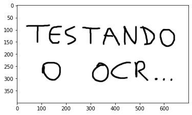

```python
img = cv2.imread('../Imagens/teste_manuscrito_01.jpg')
rgb = cv2.cvtColor(img, cv2.COLOR_BGR2RGB)

plt.imshow(rgb)
plt.show()
```

- conf = confiança da predição (de 0 a 100. -1 significa que não foi reconhecido texto)
- height = altura do bloco de texto detectada (ou seja, da caixa delimitadora)
- left = coordenada x onde inicia a caixa delimitadora
- level = o level (nível) corresponde à categoria do bloco detectado. são 5 valores possiveis:
  1. página
  2. bloco
  3. parágrafo
  4. linha
  5. palavra

Portanto, se foi retornado o valor 5 significa que o bloco detectado é texto, se foi 4 significa que o que foi detectado é uma linha

- line_num = número da linha do que foi detectado (inicia com 0)
- page_num = o índice da página onde o item foi detectado. Na maioria dos casos sempre haverá uma página só
- text = o resultado do reconhecimento
- top = coordenada y onde a caixa delimitadora começa
- width = largura do bloco de texto atual detectado
- word_num = numero da palavra (indice) dentro do bloco atual

### Realizando o image to data

```python
resultado = pytesseract.image_to_data(rgb, lang='por', output_type=Output.DICT)
resultado
```

```
{'level': [1, 2, 3, 4, 5, 4, 5, 5],
 'page_num': [1, 1, 1, 1, 1, 1, 1, 1],
 'block_num': [0, 1, 1, 1, 1, 1, 1, 1],
 'par_num': [0, 0, 1, 1, 1, 1, 1, 1],
 'line_num': [0, 0, 0, 1, 1, 2, 2, 2],
 'word_num': [0, 0, 0, 0, 1, 0, 1, 2],
 'left': [0, 38, 38, 38, 38, 102, 102, 307],
 'top': [0, 79, 79, 79, 79, 228, 233, 228],
 'width': [700, 607, 607, 607, 607, 532, 77, 327],
 'height': [400, 236, 236, 92, 92, 87, 76, 87],
 'conf': ['-1', '-1', '-1', '-1', 96, '-1', 90, 85],
 'text': ['', '', '', '', 'TESTANDO', '', 'O', 'OCR...']}
```

```python
min_conf = 20 #@param {type: 'slider', min: 0, max: 100}
```

```python
def caixa_texto(resultado, img, cor=(255, 100, 0)):

  # OBTENDO OS PARÂMETROS:
  # X0 = LEFT, YO = TOP
  # XF = LEFT + WIDTH, YF = TOP + HEIGHT

  x = resultado['left'][i]
  y = resultado['top'][i]
  w = resultado['width'][i]
  h = resultado['height'][i]

  # OS PARÂMETROS DO CV2.RECTANGLE SÃO:
  # IMAGEM
  # COORDENADAS
  # COR DO RETÂNGULO = cor = (255, 100, 0
  # ESPESSURA DO RETÂNGULO = 2
  cv2.rectangle(img, (x, y), (x + w, y + h), cor, 2)

  return x, y, img
```

```python
# QUANTIDADE DE TEXTO INICIAL
# MUITOS SENDO TEXTO '-'

print("QUANTIDADE DE TEXTO: {}".format(len(resultado['text'])))
resultado['text']
```

```
QUANTIDADE DE TEXTO: 8
```

```
['', '', '', '', 'TESTANDO', '', 'O', 'OCR...']
```

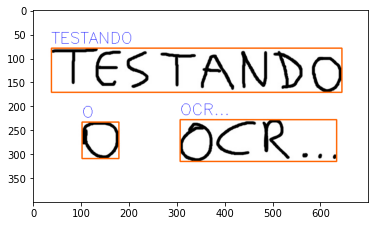

```python
img_copia = rgb.copy()

# PERCORRENDO CADA UM DOS TEXTOS OBTIDOS
for i in range(len(resultado['text'])):

  # OBTENDO O INTERVALO DE CONFIANÇA
  confianca = int(resultado['conf'][i])

  # REALIZANDO O THRESHOLD DE CONFIANÇA
  if confianca > min_conf:

    # REALIZANDO A CRIAÇÃO DA CAIXA DE TEXTO SOBRE O TEXTO
    x, y, img = caixa_texto(resultado, img_copia)

    # OBTENDO O TEXTO ATUAL
    texto = resultado['text'][i]

    # INSERINDO O TEXTO SOBRE A CAIXA RETANGULAR (TOP - 10)
    cv2.putText(img_copia, texto, (x, y - 10), cv2.FONT_HERSHEY_SIMPLEX, 1.1, (0, 0, 255))

plt.imshow(img_copia)
plt.show()
```

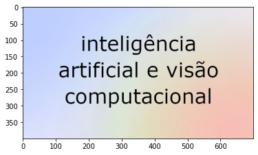

```python
img = cv2.imread('../Imagens/teste02.jpg')
rgb = cv2.cvtColor(img, cv2.COLOR_BGR2RGB)

plt.imshow(rgb)
plt.show()
```

```python
config_tesseract = "--psm 3"
resultado = pytesseract.image_to_data(rgb, config=config_tesseract, lang="por", output_type=Output.DICT)
resultado
```

```
{'level': [1, 2, 3, 4, 5, 4, 5, 5, 5, 4, 5],
 'page_num': [1, 1, 1, 1, 1, 1, 1, 1, 1, 1, 1],
 'block_num': [0, 1, 1, 1, 1, 1, 1, 1, 1, 1, 1],
 'par_num': [0, 0, 1, 1, 1, 1, 1, 1, 1, 1, 1],
 'line_num': [0, 0, 0, 1, 1, 2, 2, 2, 2, 3, 3],
 'word_num': [0, 0, 0, 0, 1, 0, 1, 2, 3, 0, 1],
 'left': [0, 111, 111, 182, 182, 111, 111, 380, 437, 130, 130],
 'top': [0, 84, 84, 84, 84, 165, 167, 179, 165, 247, 247],
 'width': [700, 481, 481, 341, 341, 481, 237, 30, 155, 440, 440],
 'height': [400, 222, 222, 62, 62, 50, 48, 36, 50, 59, 59],
 'conf': ['-1', '-1', '-1', '-1', 96, '-1', 95, 96, 96, '-1', 96],
 'text': ['',
  '',
  '',
  '',
  'inteligência',
  '',
  'artificial',
  'e',
  'visão',
  '',
  'computacional']}
```

### Importando novas fontes

```python
from PIL import ImageFont, ImageDraw, Image
fonte = '/content/calibri.ttf'
```

### Escrevendo o texto sobre a imagem

```python
def escreve_texto(texto, x, y, img, fonte, tamanho_texto=32, cor=(0, 0, 255)):

  try:
    fonte = ImageFont.truetype(fonte, tamanho_texto)

    img_pil = Image.fromarray(img)

    draw = ImageDraw.Draw(img_pil)

    draw.text((x, y - tamanho_texto), texto, font=fonte, fill=cor)

    img = np.array(img_pil)

  except Exception as ex:
    print(ex)

  return img
```

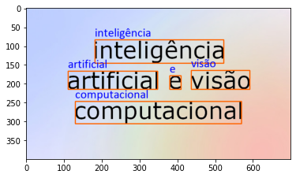

```python
img_copia = rgb.copy()

# PERCORRENDO CADA UM DOS TEXTOS OBTIDOS
for i in range(len(resultado['text'])):

  # OBTENDO O INTERVALO DE CONFIANÇA
  confianca = int(resultado['conf'][i])

  # REALIZANDO O THRESHOLD DE CONFIANÇA
  if confianca > min_conf:

    # REALIZANDO A CRIAÇÃO DA CAIXA DE TEXTO SOBRE O TEXTO
    x, y, img = caixa_texto(resultado, img_copia)

    # OBTENDO O TEXTO ATUAL
    texto = resultado['text'][i]

    # INSERINDO O TEXTO SOBRE A CAIXA RETANGULAR (TOP - 10)
    img_copia = escreve_texto(texto, x, y, img_copia, fonte)

plt.imshow(img_copia)
plt.show()
```

# Buscando informações específicas na imagem

```python
import re # regular expressions
```

```python
img = cv2.imread("Imagens/tabela_teste.jpg")
rgb = cv2.cvtColor(img, cv2.COLOR_BGR2RGB)
cv2_imshow(rgb)
```

[output not shown]

```python
config_tesseract = "--tessdata-dir tessdata"
resultado = pytesseract.image_to_data(rgb, config=config_tesseract, lang="por", output_type=Output.DICT)
```

```python
print(resultado)
```

[output not shown]

```python
padrao_data = '^(0[1-9]|[12][0-9]|3[01])/(0[1-9]|1[012])/(19|20)\d\d$'
```

```python
# INICIANDO A LISTA QUE ARMAZENARÁ TODAS AS DATAS
datas = []

img_copia = rgb.copy()

# PERCORRENDO CADA UM DOS TEXTOS OBTIDOS
for i in range(0, len(resultado['text'])):

  # OBTENDO O INTERVALO DE CONFIANÇA
  confianca = int(resultado['conf'][i])

  # REALIZANDO O THRESHOLD DE CONFIANÇA
  if confianca > min_conf:

    # OBTENDO O TEXTO ATUAL
    texto = resultado['text'][i]

    # VERIFICANDO SE O TEXTO POSSUI O PADRÃO DE REGEX BUSCADO
    if re.match(padrao_data, texto):

      # CASO POSSUA O PADRÃO DE REGEX COLOCA O TEXTO
      # INSERINDO O TEXTO SOBRE A CAIXA RETANGULAR (TOP - 10)
      img_copia = escreve_texto(texto, x, y, img_copia, fonte, 12)
      datas.append(texto)

    # CRIA O BOUNDING BOX SOBRE O TEXTO
    x, y, img_copia = caixa_texto(resultado, img_copia)


cv2_imshow(img_copia)
```

[output not shown]

```python
datas
```

[output not shown]

```python
# OBTENDO APENAS DIGITOS (NÃO FUNCIONA NA VERSÃO 4.0 DO TESSERACT)

custom_config = 'digits'
print(pytesseract.image_to_string(rgb, config=custom_config, lang="por"))
```

# Detecção de texto em cenários naturais

```python
img = cv2.imread("Imagens/caneca.jpg")
rgb = cv2.cvtColor(img, cv2.COLOR_BGR2RGB)
cv2_imshow(rgb)
```

[output not shown]

```python
resultado = pytesseract.image_to_data(rgb, lang="por", output_type=Output.DICT)
resultado
```

[output not shown]

```python
img_copia = rgb.copy()

# PERCORRENDO CADA UM DOS TEXTOS OBTIDOS
for i in range(len(resultado['text'])):

  # OBTENDO O INTERVALO DE CONFIANÇA
  confianca = int(resultado['conf'][i])

  # REALIZANDO O THRESHOLD DE CONFIANÇA
  if confianca > min_conf:

    # REALIZANDO A CRIAÇÃO DA CAIXA DE TEXTO SOBRE O TEXTO
    x, y, img = caixa_texto(resultado, img_copia)

    # OBTENDO O TEXTO ATUAL
    texto = resultado['text'][i]

    # INSERINDO O TEXTO SOBRE A CAIXA RETANGULAR (TOP - 10)
    img_copia = escreve_texto(texto, x, y, img_copia, fonte)

cv2_imshow(img_copia)
```

[output not shown]

```python
resultado['conf']
```

```python
resultado['text']
```

```python
img_copia = rgb.copy()

# PERCORRENDO CADA UM DOS TEXTOS OBTIDOS
for i in range(len(resultado['text'])):

  # OBTENDO O INTERVALO DE CONFIANÇA
  confianca = int(resultado['conf'][i])
  text = resultado['text'][i]

  # REALIZANDO O THRESHOLD DE CONFIANÇA
  if confianca > min_conf and not text.isspace() and len(text) > 1:

    # REALIZANDO A CRIAÇÃO DA CAIXA DE TEXTO SOBRE O TEXTO
    x, y, img = caixa_texto(resultado, img_copia)

    # OBTENDO O TEXTO ATUAL
    texto = resultado['text'][i]

    # INSERINDO O TEXTO SOBRE A CAIXA RETANGULAR (TOP - 10)
    img_copia = escreve_texto(texto, x, y, img_copia, fonte)

cv2_imshow(img_copia)
```

[output not shown]